# 2025 Elections: Market Votes Data

2024-10-29

## Exploratory Data Analysis

### Summary of Key Findings

- **Akbayan does not have areas that would be considered clear or strong bailiwicks**. Instead, Akbayan’s votes were spread out as the party garnered at least one vote in **1,596 cities/municipalities**.
- **Akbayan tends to fare better in more competitive localities**. One measure of competitiveness is the **Herfindahl-Hirschman Index (HHI)**, which is calculated as the sum of the squares of the market shares (in this case, the vote shares) of all party-lists in a given city/municipality. The formula is:

$$HHI = \sum_{i=1}^n s_i^2$$

where $s^2$ is the vote share of party-list $i$ in a city/municipality and $N$ is the total number of party-lists in that city/municipality.

- **Akbayan performs best in localities with HHI not greater than 0.25**. Low HHI values indicate a highly competitive environment. This occurs when many party-lists have relatively equal shares of the votes. High HHI values suggest concentration or dominance, meaning one or a few party-lists hold a large share of the votes.
- **Akbayan performs best in localities when there is no dominant party-list garnering over 40% of PL votes.**
- **Akbayan’s performance in a locality correlates with Chel Diokno’s senatorial performance in the same locality**. The correlation also exists between Akbayan’s performance and Risa Hontiveros’ senatorial performance, albeit to a weaker extent. When controlling for both variables, it seems that Chel’s performance in an area was more predictive of Akbayan’s performance.

```r
lm_chel <- lm(akbayan_vote_share ~ chel_ratio01 + hhi + log(total_plvotes),
   data = vote_strat_data)
lm_risa <- lm(akbayan_vote_share ~ risa_ratio01 + hhi + log(total_plvotes),
   data = vote_strat_data)
lm_chelrisa <- lm(akbayan_vote_share ~ chel_ratio01 + risa_ratio01 + hhi + log(total_plvotes),
   data = vote_strat_data)

stargazer(lm_chel, lm_risa, lm_chelrisa,
          type="html", out="test.html", out.header=TRUE)
```

|  | *Dependent variable:* |  |  |
| --- | --- | --- | --- |
|  | akbayan_vote_share |  |  |
|  | (1) | (2) | (3) |
| chel_ratio01 | 0.008*** |  | 0.005*** |
|  | (0.001) |  | (0.002) |
| risa_ratio01 |  | 0.006*** | 0.003** |
|  |  | (0.001) | (0.001) |
| hhi | -0.008*** | -0.008*** | -0.008*** |
|  | (0.001) | (0.001) | (0.001) |
| log(total_plvotes) | 0.0005*** | 0.001*** | 0.0005*** |
|  | (0.0002) | (0.0002) | (0.0002) |
| Constant | -0.001 | -0.003* | -0.002 |
|  | (0.002) | (0.002) | (0.002) |
| Observations | 1,654 | 1,654 | 1,654 |
| R<sup>2</sup> | 0.105 | 0.104 | 0.108 |
| Adjusted R<sup>2</sup> | 0.104 | 0.102 | 0.106 |
| Residual Std. Error | 0.006 (df = 1650) | 0.006 (df = 1650) | 0.006 (df = 1649) |
| F Statistic | 64.798*** (df = 3; 1650) | 63.601*** (df = 3; 1650) | 49.778*** (df = 4; 1649) |
| *Note:* | p<0.1; p<0.05; p<0.01 |  |  |

### Party-list Bailiwicks

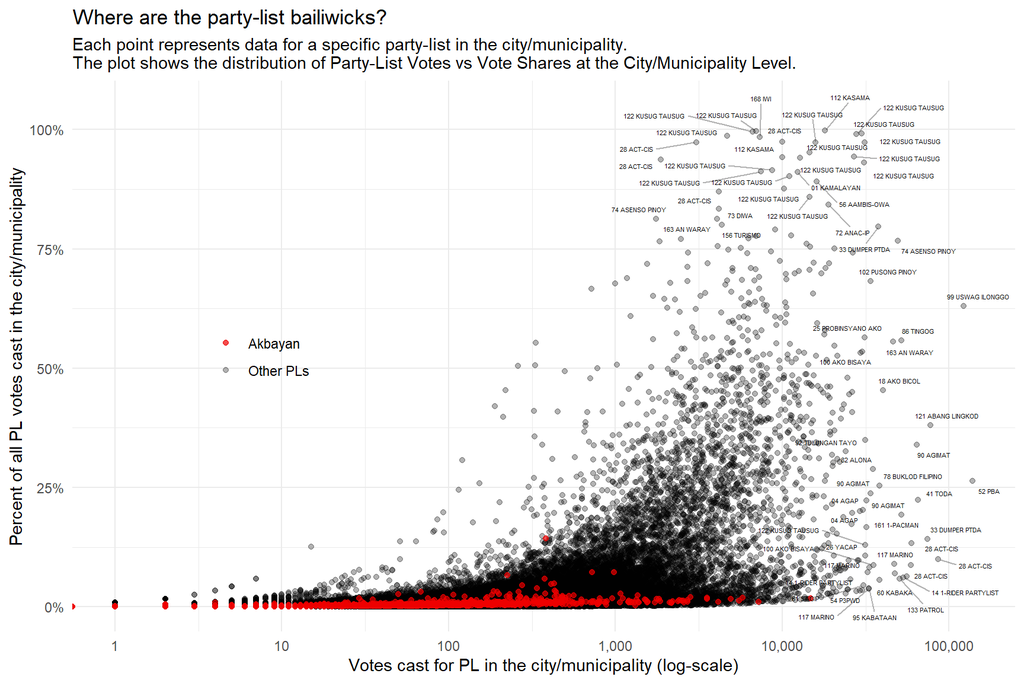

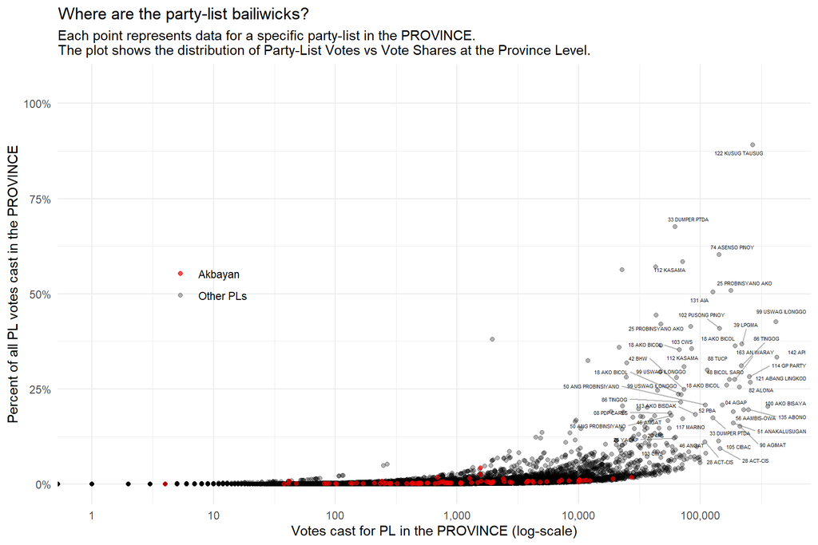

### Party-list Landscape

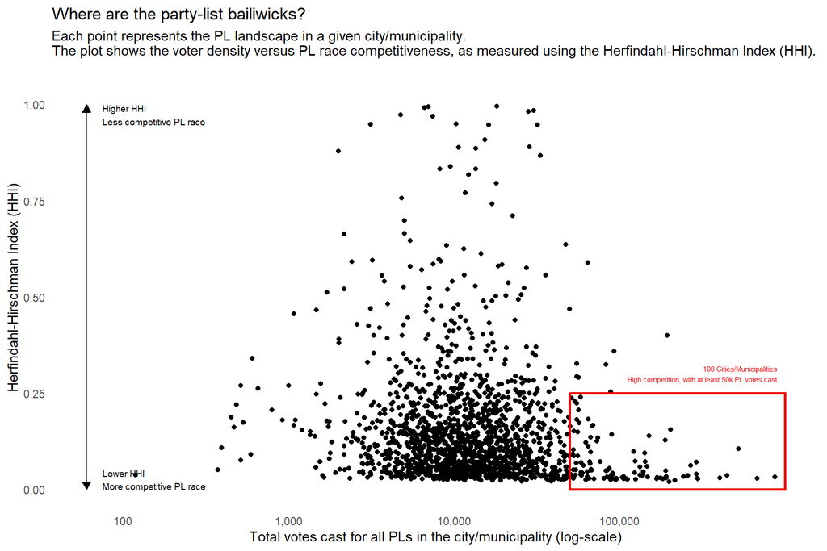

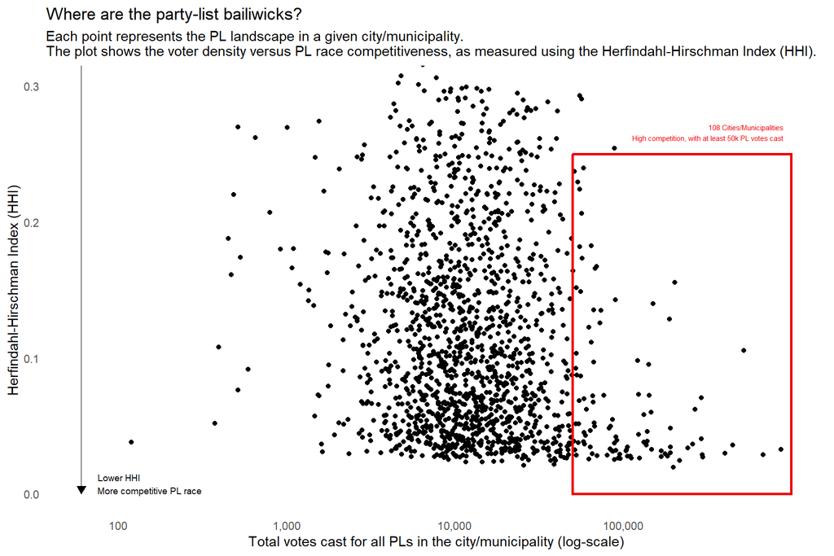

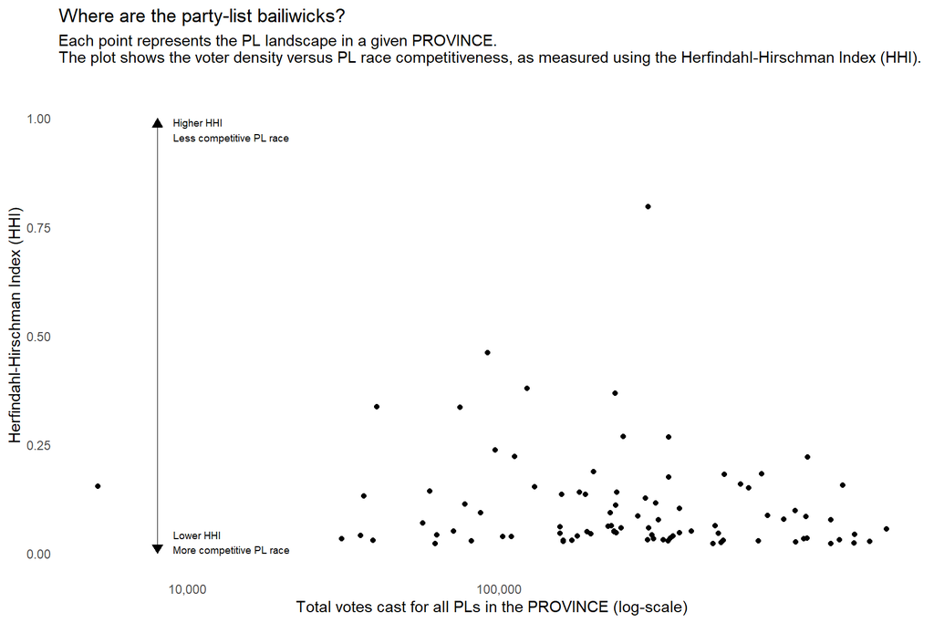

### Akbayan Performance

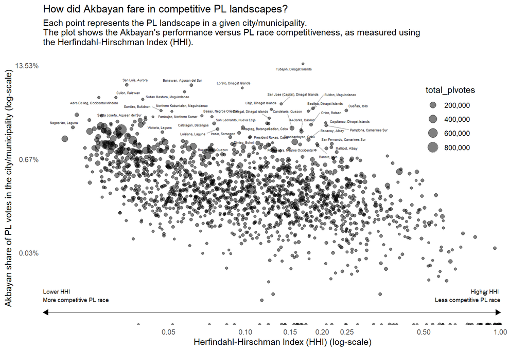

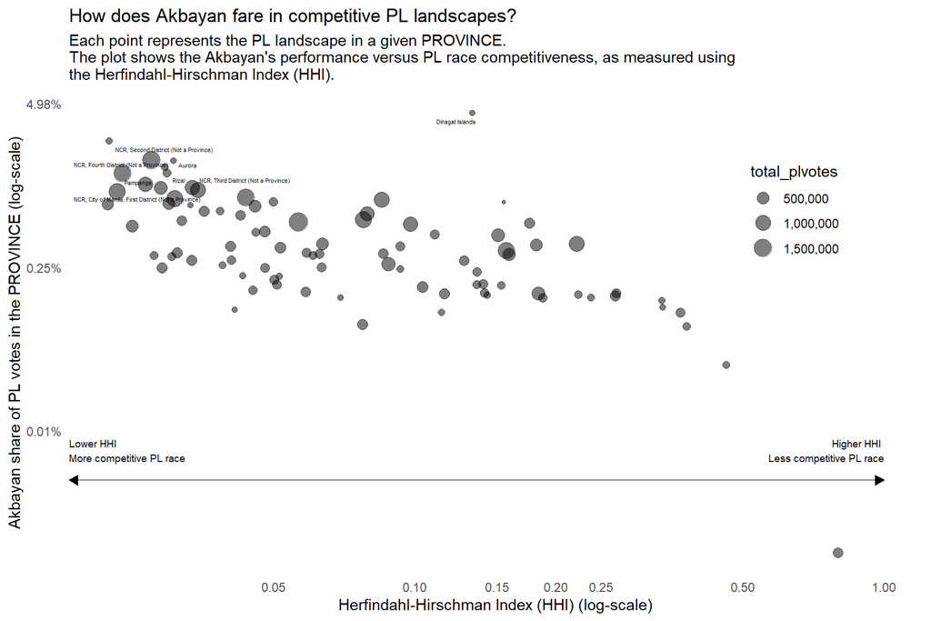

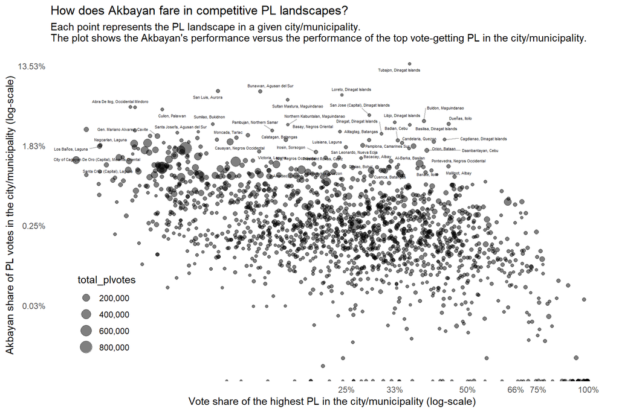

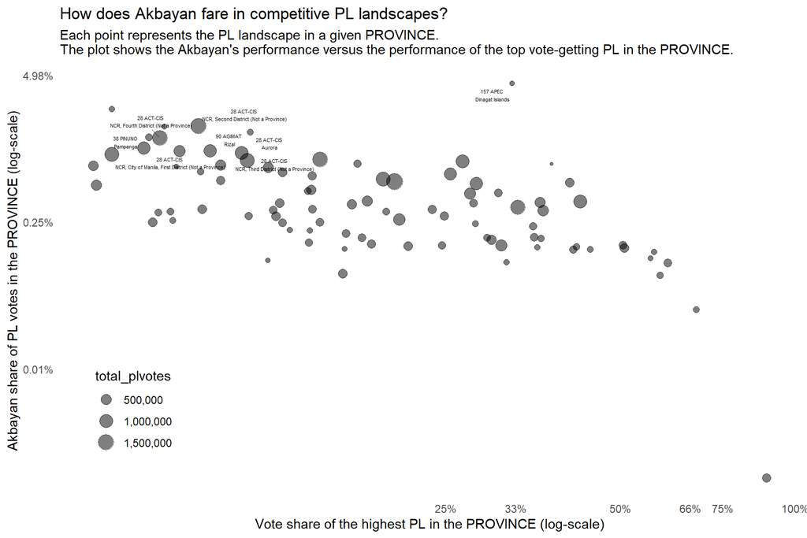

### Chel and Akbayan Voting Areas

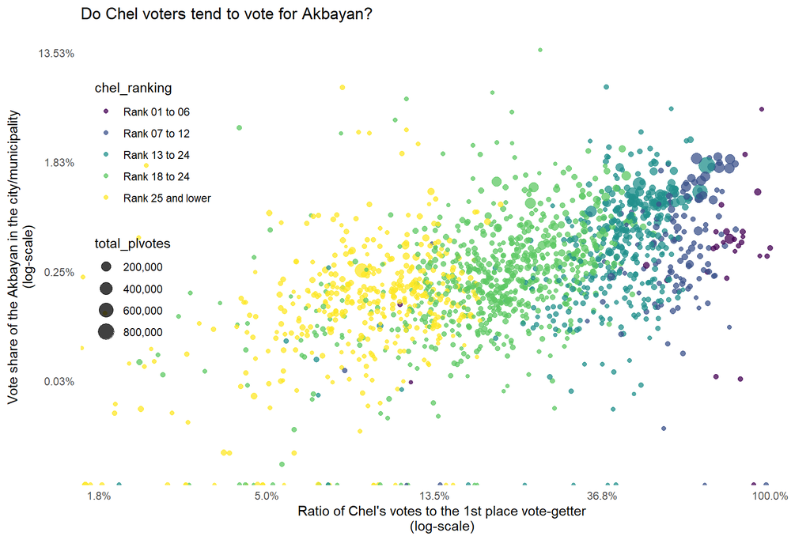

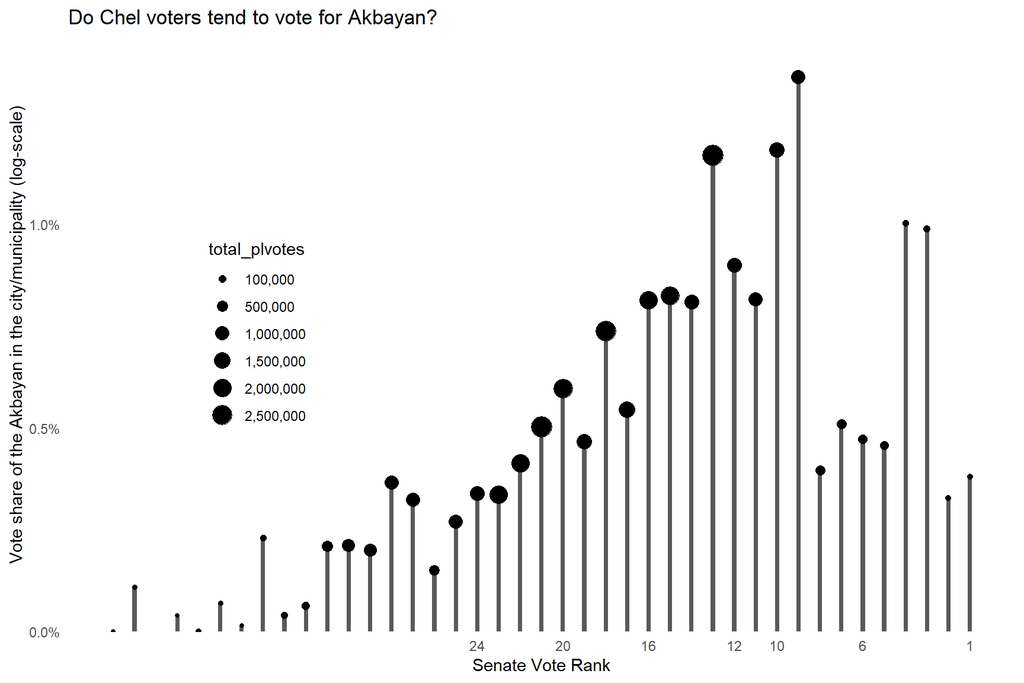

### Risa and Akbayan Voting Areas

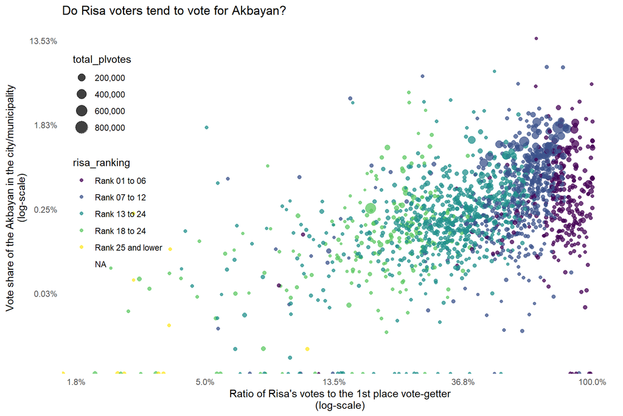

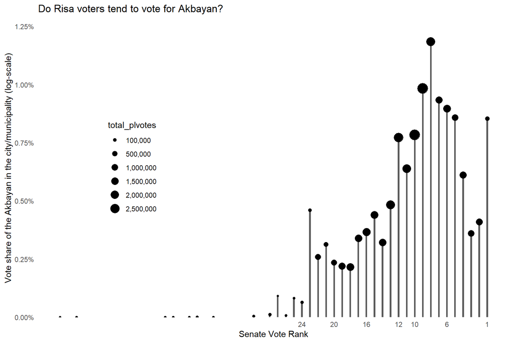

### Chel and Risa Voting Areas

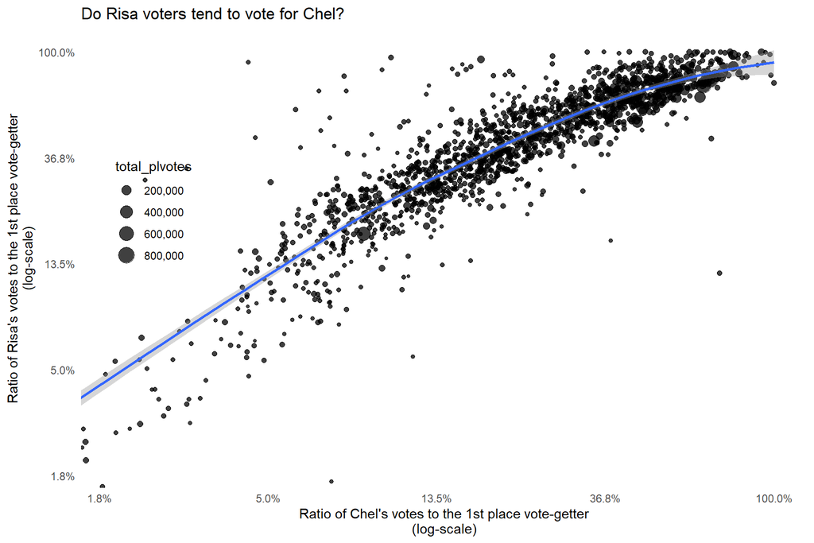

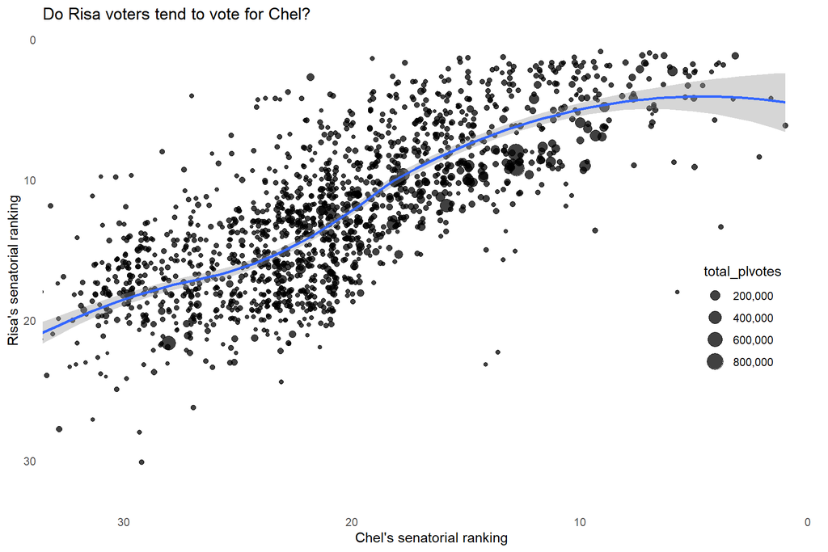

## Identifying Strategic Areas

### Filtering and Sorting Algorithm to Identify Market Areas

#### 1. Target Chel Voters

- Given that Chel is the party’s first nominee, we can leverage voters who were already inclined to vote for Chel in the previous election.
- To be conservative, we can subtract the votes garnered by the highest vote-getting PL from the number of Chel voters in an area:

$$MarketVotes = Votes_{Chel} - Votes_{Highest PL}$$

#### 2. Apply Filters for Competitiveness

- Non-zero market votes, i.e., Chel’s votes must be higher than the votes of the highest vote-getting PL
- Chel ranked at **least 18th** in the Senate race
- Herfindahl-Hirschman Index (**HHI**) not greater than **0.25**
- Percent share of the **highest vote-getting PL** not greater than **25%**

#### 3. Apply sorting based on voter density

- Sort based on the areas with the largest number of market votes

#### Nominal Target: Convert **20%** of Chel Market Votes

### Results

| n | market_votes | chel_votes | akbayan_votes | target20percent |
| --- | --- | --- | --- | --- |
| 228 | 3,107,206 | 4,657,770 | 129,896 | 621,441 |

#### By Market Vote Decile

| market_votes_decile | n | market_votes | chel_votes | akbayan_votes | target20percent |
| --- | --- | --- | --- | --- | --- |
| 10 | 23 | 1,862,880 | 2,535,174 | 79,376 | 372,586 |
| 09 | 23 | 531,942 | 769,695 | 21,570 | 106,397 |
| 08 | 23 | 239,200 | 383,169 | 8,622 | 47,848 |
| 07 | 22 | 151,593 | 248,294 | 4,499 | 30,331 |
| 06 | 23 | 109,773 | 218,196 | 5,396 | 21,964 |
| 05 | 23 | 84,920 | 166,450 | 3,798 | 16,992 |
| 04 | 22 | 60,072 | 136,549 | 2,560 | 12,024 |
| 03 | 23 | 38,658 | 85,621 | 2,119 | 7,740 |
| 02 | 23 | 20,722 | 65,523 | 1,296 | 4,154 |
| 01 | 23 | 7,446 | 49,099 | 660 | 1,498 |

| market_votes_decile | n | market_votes_share | chel_votes_share | akbayan_votes_share | target20percent_share |
| --- | --- | --- | --- | --- | --- |
| 10 | 23 | 0.600 | 0.544 | 0.611 | 0.599 |
| 09 | 23 | 0.171 | 0.165 | 0.166 | 0.171 |
| 08 | 23 | 0.077 | 0.082 | 0.066 | 0.077 |
| 07 | 22 | 0.049 | 0.053 | 0.035 | 0.049 |
| 06 | 23 | 0.035 | 0.047 | 0.042 | 0.035 |
| 05 | 23 | 0.027 | 0.036 | 0.029 | 0.027 |
| 04 | 22 | 0.019 | 0.029 | 0.020 | 0.019 |
| 03 | 23 | 0.012 | 0.018 | 0.016 | 0.012 |
| 02 | 23 | 0.007 | 0.014 | 0.010 | 0.007 |
| 01 | 23 | 0.002 | 0.011 | 0.005 | 0.002 |

### Full List

|  | Province | City/Municipality | Market Votes | Chel Votes | Total PL Votes | Akbayan Votes | Votes of Highest PL | Target Votes (20)% |
| --- | --- | --- | --- | --- | --- | --- | --- | --- |
| 1 | NCR, Second District (Not a Province) | Quezon City | 297624 | 383924 | 867199 | 14869 | 86300 | 59524.8 |
| 2 | NCR, City of Manila, First District (Not a Province) | City of Manila | 229532 | 288766 | 681061 | 7227 | 59234 | 45906.4 |
| 3 | NCR, Fourth District (Not a Province) | City of Makati | 120714 | 144555 | 297236 | 5792 | 23841 | 24142.8 |
| 4 | NCR, Second District (Not a Province) | City of Pasig | 116832 | 145575 | 296603 | 4906 | 28743 | 23366.4 |
| 5 | NCR, Third District (Not a Province) | City of Caloocan | 101215 | 160771 | 448333 | 5497 | 59556 | 20243 |
| 6 | Cebu | City of Cebu (Capital) | 91003 | 126234 | 404736 | 4153 | 35231 | 18200.6 |
| 7 | NCR, Fourth District (Not a Province) | City of Parañaque | 88620 | 105717 | 216876 | 3537 | 17097 | 17724 |
| 8 | NCR, Second District (Not a Province) | City of Marikina | 78244 | 91844 | 183466 | 3542 | 13600 | 15648.8 |
| 9 | NCR, Fourth District (Not a Province) | City of Taguig | 71349 | 102687 | 291010 | 2579 | 31338 | 14269.8 |
| 10 | NCR, Fourth District (Not a Province) | City of Muntinlupa | 68011 | 88459 | 191481 | 2699 | 20448 | 13602.2 |

[output cut: 218 more lines]

## Maximizing non-Chel Markets - Risa Voters

#### 1. Target Risa Voters

- Outside of areas where Chel performed relatively well, we can create a targetting algorithm based on **Risa’s** voters.
- To be conservative, we can subtract the votes garnered by the highest vote-getting PL from the number of **Risa** voters in an area

$$MarketVotes = Votes_{Risa} - Votes_{Highest PL}$$

#### 2. Apply Filters for Competitiveness

- Non-zero market votes, i.e., Risa’s votes must be higher than the votes of the highest vote-getting PL
- Risa ranked **at least 12th** in the Senate race
- Chel ranked at **below 18th** in the Senate race
- Herfindahl-Hirschman Index (**HHI**) not greater than **0.25**
- Percent share of the **highest vote-getting PL** not greater than **25%**

#### 3. Apply sorting based on voter density

- Sort based on the areas with the largest number of market votes

#### Nominal Target: Convert **5%** of Risa Market Votes

### Results

| n | market_votes | risa_votes | akbayan_votes | target05percent |
| --- | --- | --- | --- | --- |
| 160 | 963,393 | 1,478,807 | 23,065 | 48,170 |

#### By Market Vote Decile

| market_votes_decile | n | market_votes | risa_votes | akbayan_votes | target05percent |
| --- | --- | --- | --- | --- | --- |
| 10 | 16 | 467,019 | 664,618 | 13,281 | 23,360 |
| 09 | 16 | 137,835 | 214,430 | 4,102 | 6,902 |
| 08 | 16 | 89,132 | 149,095 | 1,615 | 4,467 |
| 07 | 16 | 68,798 | 112,075 | 837 | 3,444 |
| 06 | 16 | 57,702 | 87,858 | 708 | 2,893 |
| 05 | 16 | 47,092 | 71,243 | 913 | 2,361 |
| 04 | 16 | 35,387 | 58,693 | 503 | 1,778 |
| 03 | 16 | 27,587 | 49,671 | 688 | 1,387 |
| 02 | 16 | 20,425 | 45,244 | 284 | 1,030 |
| 01 | 16 | 12,416 | 25,880 | 134 | 629 |

| market_votes_decile | n | market_votes_share | risa_votes_share | akbayan_votes_share | target05percent_share |
| --- | --- | --- | --- | --- | --- |
| 10 | 16 | 0.485 | 0.449 | 0.576 | 0.484 |
| 09 | 16 | 0.143 | 0.145 | 0.178 | 0.143 |
| 08 | 16 | 0.093 | 0.101 | 0.070 | 0.093 |
| 07 | 16 | 0.071 | 0.076 | 0.036 | 0.071 |
| 06 | 16 | 0.060 | 0.059 | 0.031 | 0.060 |
| 05 | 16 | 0.049 | 0.048 | 0.040 | 0.049 |
| 04 | 16 | 0.037 | 0.040 | 0.022 | 0.037 |
| 03 | 16 | 0.029 | 0.034 | 0.030 | 0.029 |
| 02 | 16 | 0.021 | 0.031 | 0.012 | 0.021 |
| 01 | 16 | 0.013 | 0.018 | 0.006 | 0.013 |

### Full List

[output not shown]

[output cut: 150 more lines]